# About the project

# Implemting Logistic Regression

#### logistic regression is a classification algorithm that uses the logistic function to classify the data.

#### Logistic regression estimates the probability of an event occurring, based on a given dataset of independent variables. Since the outcome is a probability, the dependent variable is bounded between 0 and 1.

#### in this case, the logistic function is used to calculate the probability of a given data point belonging to a certain class

#### benign (harmless) or malignant (harmful).

```
0.9824561403508771
```

```
<sklearn.metrics._plot.confusion_matrix.ConfusionMatrixDisplay at 0x7fd82f5a19d0>
```

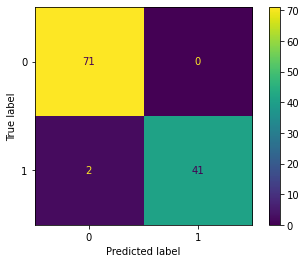

```python
lr = LogisticRegression()
lr.fit(X_train, y_train)
pred_lr = lr.predict(X_test)
print(accuracy_score(y_test, pred_lr))

cm = confusion_matrix(y_test, pred_lr, labels=lr.classes_)
disp = ConfusionMatrixDisplay(confusion_matrix=cm,display_labels=lr.classes_)
disp.plot()
```

```python
# implemnting cross_val_score to check the accuracy of the model.
from sklearn.model_selection import cross_val_score
scores = cross_val_score(lr, X_train, y_train, cv=5)
print(scores)
```

```
[0.96703297 0.95604396 0.98901099 0.94505495 0.94505495]
```

# Feature importance

#### Feature Importance refers to techniques that calculate a score for all the input features for a given model.

#### the scores simply represent the “importance” of each feature. A higher score means that the specific feature will have a larger effect on the model that is being used to predict a certain variable.

#### one of the many ways to check feature importance is to check to coeffiecients of the model.

For example, both linear and logistic regression algorithms have a coeffiecient that represents the weight of each feature. for each feature if an assigned coefficient is a large (negative or positive) number, it has some influence on the prediction. On the contrary, if the coefficient is zero, it doesn't have any impact on the prediction.

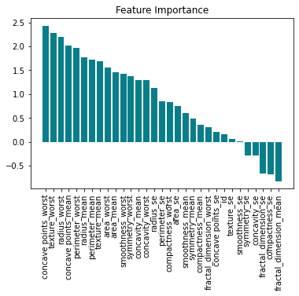

```python
from sklearn.inspection import permutation_importance # Permutation importance is a method that is used to determine the importance of the features in the model.
from sklearn.metrics import r2_score # r2_score is a function that calculates the r2 score of the model

feutre_importance = permutation_importance(lr, X_test, y_test, n_repeats=10, random_state=42)
importances = pd.DataFrame(data={
    'Attribute': X_train.columns,
    'Importance': lr.coef_[0]
})


importances = importances.sort_values(by='Importance', ascending=False)
plt.bar(x=importances['Attribute'], height=importances['Importance'], color='#087E8B')
plt.title('Feature Importance')
plt.xticks(rotation=90)
plt.show()
```